# loan_defaulter_prediction_pre-processing

```python
# Import necessary packages for data analysis and visualization
import numpy as np
import pandas as pd
import seaborn as sns
import scipy.stats as stats
import matplotlib.pyplot as plt
import pingouin as pg
```

```python
# Read the CSV file into a DataFrame
df = pd.read_csv(r'C:\Users\br1gi\Downloads\Loan Defaulter Prediction\application_data.csv')
df.head(1)
```

|  | SK_ID_CURR | TARGET | NAME_CONTRACT_TYPE | CODE_GENDER | FLAG_OWN_CAR | FLAG_OWN_REALTY | CNT_CHILDREN | AMT_INCOME_TOTAL | AMT_CREDIT | AMT_ANNUITY | ... | FLAG_DOCUMENT_18 | FLAG_DOCUMENT_19 | FLAG_DOCUMENT_20 | FLAG_DOCUMENT_21 | AMT_REQ_CREDIT_BUREAU_HOUR | AMT_REQ_CREDIT_BUREAU_DAY | AMT_REQ_CREDIT_BUREAU_WEEK | AMT_REQ_CREDIT_BUREAU_MON | AMT_REQ_CREDIT_BUREAU_QRT | AMT_REQ_CREDIT_BUREAU_YEAR |
| --- | --- | --- | --- | --- | --- | --- | --- | --- | --- | --- | --- | --- | --- | --- | --- | --- | --- | --- | --- | --- | --- |
| 0 | 100002 | 1 | Cash loans | M | N | Y | 0 | 202500.0 | 406597.5 | 24700.5 | ... | 0 | 0 | 0 | 0 | 0.0 | 0.0 | 0.0 | 0.0 | 0.0 | 1.0 |

1 rows × 122 columns

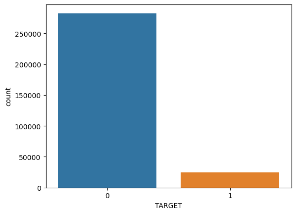

```python
# Create a count plot to visualize the distribution of the 'TARGET' column
sns.countplot(data=df, x='TARGET')
```

```python
# Generate descriptive statistics for numerical columns
df.describe()
```

|  | SK_ID_CURR | TARGET | CNT_CHILDREN | AMT_INCOME_TOTAL | AMT_CREDIT | AMT_ANNUITY | AMT_GOODS_PRICE | REGION_POPULATION_RELATIVE | DAYS_BIRTH | DAYS_EMPLOYED | ... | FLAG_DOCUMENT_18 | FLAG_DOCUMENT_19 | FLAG_DOCUMENT_20 | FLAG_DOCUMENT_21 | AMT_REQ_CREDIT_BUREAU_HOUR | AMT_REQ_CREDIT_BUREAU_DAY | AMT_REQ_CREDIT_BUREAU_WEEK | AMT_REQ_CREDIT_BUREAU_MON | AMT_REQ_CREDIT_BUREAU_QRT | AMT_REQ_CREDIT_BUREAU_YEAR |
| --- | --- | --- | --- | --- | --- | --- | --- | --- | --- | --- | --- | --- | --- | --- | --- | --- | --- | --- | --- | --- | --- |
| count | 307511.000000 | 307511.000000 | 307511.000000 | 3.075110e+05 | 3.075110e+05 | 307499.000000 | 3.072330e+05 | 307511.000000 | 307511.000000 | 307511.000000 | ... | 307511.000000 | 307511.000000 | 307511.000000 | 307511.000000 | 265992.000000 | 265992.000000 | 265992.000000 | 265992.000000 | 265992.000000 | 265992.000000 |
| mean | 278180.518577 | 0.080729 | 0.417052 | 1.687979e+05 | 5.990260e+05 | 27108.573909 | 5.383962e+05 | 0.020868 | -16036.995067 | 63815.045904 | ... | 0.008130 | 0.000595 | 0.000507 | 0.000335 | 0.006402 | 0.007000 | 0.034362 | 0.267395 | 0.265474 | 1.899974 |
| std | 102790.175348 | 0.272419 | 0.722121 | 2.371231e+05 | 4.024908e+05 | 14493.737315 | 3.694465e+05 | 0.013831 | 4363.988632 | 141275.766519 | ... | 0.089798 | 0.024387 | 0.022518 | 0.018299 | 0.083849 | 0.110757 | 0.204685 | 0.916002 | 0.794056 | 1.869295 |
| min | 100002.000000 | 0.000000 | 0.000000 | 2.565000e+04 | 4.500000e+04 | 1615.500000 | 4.050000e+04 | 0.000290 | -25229.000000 | -17912.000000 | ... | 0.000000 | 0.000000 | 0.000000 | 0.000000 | 0.000000 | 0.000000 | 0.000000 | 0.000000 | 0.000000 | 0.000000 |
| 25% | 189145.500000 | 0.000000 | 0.000000 | 1.125000e+05 | 2.700000e+05 | 16524.000000 | 2.385000e+05 | 0.010006 | -19682.000000 | -2760.000000 | ... | 0.000000 | 0.000000 | 0.000000 | 0.000000 | 0.000000 | 0.000000 | 0.000000 | 0.000000 | 0.000000 | 0.000000 |
| 50% | 278202.000000 | 0.000000 | 0.000000 | 1.471500e+05 | 5.135310e+05 | 24903.000000 | 4.500000e+05 | 0.018850 | -15750.000000 | -1213.000000 | ... | 0.000000 | 0.000000 | 0.000000 | 0.000000 | 0.000000 | 0.000000 | 0.000000 | 0.000000 | 0.000000 | 1.000000 |
| 75% | 367142.500000 | 0.000000 | 1.000000 | 2.025000e+05 | 8.086500e+05 | 34596.000000 | 6.795000e+05 | 0.028663 | -12413.000000 | -289.000000 | ... | 0.000000 | 0.000000 | 0.000000 | 0.000000 | 0.000000 | 0.000000 | 0.000000 | 0.000000 | 0.000000 | 3.000000 |
| max | 456255.000000 | 1.000000 | 19.000000 | 1.170000e+08 | 4.050000e+06 | 258025.500000 | 4.050000e+06 | 0.072508 | -7489.000000 | 365243.000000 | ... | 1.000000 | 1.000000 | 1.000000 | 1.000000 | 4.000000 | 9.000000 | 8.000000 | 27.000000 | 261.000000 | 25.000000 |

8 rows × 106 columns

```python
# Display concise information about the DataFrame
df.info(verbose=True)
```

```
<class 'pandas.core.frame.DataFrame'>
RangeIndex: 307511 entries, 0 to 307510
Data columns (total 122 columns):
 #    Column                        Dtype
---   ------                        -----
 0    SK_ID_CURR                    int64
 1    TARGET                        int64
 2    NAME_CONTRACT_TYPE            object
 3    CODE_GENDER                   object
 4    FLAG_OWN_CAR                  object
 5    FLAG_OWN_REALTY               object
 6    CNT_CHILDREN                  int64
 7    AMT_INCOME_TOTAL              float64
 8    AMT_CREDIT                    float64
 9    AMT_ANNUITY                   float64
```

[output cut: 114 more lines]

```python
# Calculate the percentage of missing values for each column
null = df.isnull().sum() * 100 / len(df)
```

```python
# Filter columns with missing value percentages greater than 25%
null_above_25 = null[null > 25]
null_above_25
```

```
OWN_CAR_AGE                     65.990810
OCCUPATION_TYPE                 31.345545
EXT_SOURCE_1                    56.381073
APARTMENTS_AVG                  50.749729
BASEMENTAREA_AVG                58.515956
YEARS_BEGINEXPLUATATION_AVG     48.781019
YEARS_BUILD_AVG                 66.497784
COMMONAREA_AVG                  69.872297
ELEVATORS_AVG                   53.295980
ENTRANCES_AVG                   50.348768
FLOORSMAX_AVG                   49.760822
FLOORSMIN_AVG                   67.848630
LANDAREA_AVG                    59.376738
LIVINGAPARTMENTS_AVG            68.354953
LIVINGAREA_AVG                  50.193326
NONLIVINGAPARTMENTS_AVG         69.432963
NONLIVINGAREA_AVG               55.179164
APARTMENTS_MODE                 50.749729
BASEMENTAREA_MODE               58.515956
YEARS_BEGINEXPLUATATION_MODE    48.781019
YEARS_BUILD_MODE                66.497784
COMMONAREA_MODE                 69.872297
ELEVATORS_MODE                  53.295980
ENTRANCES_MODE                  50.348768
FLOORSMAX_MODE                  49.760822
FLOORSMIN_MODE                  67.848630
LANDAREA_MODE                   59.376738
LIVINGAPARTMENTS_MODE           68.354953
LIVINGAREA_MODE                 50.193326
NONLIVINGAPARTMENTS_MODE        69.432963
NONLIVINGAREA_MODE              55.179164
APARTMENTS_MEDI                 50.749729
BASEMENTAREA_MEDI               58.515956
YEARS_BEGINEXPLUATATION_MEDI    48.781019
YEARS_BUILD_MEDI                66.497784
COMMONAREA_MEDI                 69.872297
ELEVATORS_MEDI                  53.295980
ENTRANCES_MEDI                  50.348768
FLOORSMAX_MEDI                  49.760822
FLOORSMIN_MEDI                  67.848630
LANDAREA_MEDI                   59.376738
LIVINGAPARTMENTS_MEDI           68.354953
LIVINGAREA_MEDI                 50.193326
NONLIVINGAPARTMENTS_MEDI        69.432963
NONLIVINGAREA_MEDI              55.179164
FONDKAPREMONT_MODE              68.386172
HOUSETYPE_MODE                  50.176091
TOTALAREA_MODE                  48.268517
WALLSMATERIAL_MODE              50.840783
EMERGENCYSTATE_MODE             47.398304
dtype: float64
```

```python
# Calculate the proportion of missing values for each column
missing_proportions = df.isna().sum() / len(df)
```

```python
# Identify column names with missing value proportions greater than 25%
na_above_25 = missing_proportions[missing_proportions > 0.25].index
na_list = list(na_above_25)
na_above_25
```

```
Index(['OWN_CAR_AGE', 'OCCUPATION_TYPE', 'EXT_SOURCE_1', 'APARTMENTS_AVG',
       'BASEMENTAREA_AVG', 'YEARS_BEGINEXPLUATATION_AVG', 'YEARS_BUILD_AVG',
       'COMMONAREA_AVG', 'ELEVATORS_AVG', 'ENTRANCES_AVG', 'FLOORSMAX_AVG',
       'FLOORSMIN_AVG', 'LANDAREA_AVG', 'LIVINGAPARTMENTS_AVG',
       'LIVINGAREA_AVG', 'NONLIVINGAPARTMENTS_AVG', 'NONLIVINGAREA_AVG',
       'APARTMENTS_MODE', 'BASEMENTAREA_MODE', 'YEARS_BEGINEXPLUATATION_MODE',
       'YEARS_BUILD_MODE', 'COMMONAREA_MODE', 'ELEVATORS_MODE',
       'ENTRANCES_MODE', 'FLOORSMAX_MODE', 'FLOORSMIN_MODE', 'LANDAREA_MODE',
       'LIVINGAPARTMENTS_MODE', 'LIVINGAREA_MODE', 'NONLIVINGAPARTMENTS_MODE',
       'NONLIVINGAREA_MODE', 'APARTMENTS_MEDI', 'BASEMENTAREA_MEDI',
       'YEARS_BEGINEXPLUATATION_MEDI', 'YEARS_BUILD_MEDI', 'COMMONAREA_MEDI',
       'ELEVATORS_MEDI', 'ENTRANCES_MEDI', 'FLOORSMAX_MEDI', 'FLOORSMIN_MEDI',
       'LANDAREA_MEDI', 'LIVINGAPARTMENTS_MEDI', 'LIVINGAREA_MEDI',
       'NONLIVINGAPARTMENTS_MEDI', 'NONLIVINGAREA_MEDI', 'FONDKAPREMONT_MODE',
       'HOUSETYPE_MODE', 'TOTALAREA_MODE', 'WALLSMATERIAL_MODE',
       'EMERGENCYSTATE_MODE'],
      dtype='object')
```

# Check the columns to be dropped

### OWN_CAR_AGE

```python
# Check the number of null values in the 'OWN_CAR_AGE' column
df['OWN_CAR_AGE'].isnull().sum()
```

```
202929
```

```python
# Check the number of null values in the 'FLAG_OWN_CAR' column
df['FLAG_OWN_CAR'].isnull().sum()
```

```
0
```

```python
# Display the value counts of the 'FLAG_OWN_CAR' column
df['FLAG_OWN_CAR'].value_counts()
```

```
FLAG_OWN_CAR
N    202924
Y    104587
Name: count, dtype: int64
```

```python
# Display the value counts of the 'FLAG_OWN_CAR' column for rows with null 'OWN_CAR_AGE'
df[df['OWN_CAR_AGE'].isnull()]['FLAG_OWN_CAR'].value_counts()
```

```
FLAG_OWN_CAR
N    202924
Y         5
Name: count, dtype: int64
```

#### Other than 5 null values in the OWN_CAR_AGE, the rest are due to the lack of car.

```python
# Calculate the percentage of null values in the 'OWN_CAR_AGE' column
df['OWN_CAR_AGE'].isnull().sum()*100/len(df)
```

```
65.9908100848425
```

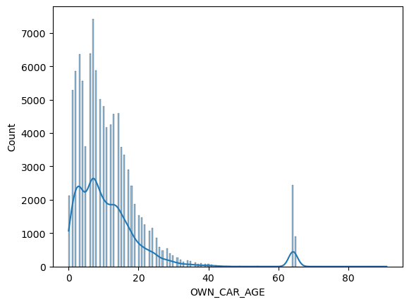

```python
# Create a histogram for the 'OWN_CAR_AGE' column
sns.histplot(data=df, x='OWN_CAR_AGE', kde=True)
```

```python
# Display descriptive statistics for the 'OWN_CAR_AGE' column
df['OWN_CAR_AGE'].describe()
```

```
count    104582.000000
mean         12.061091
std          11.944812
min           0.000000
25%           5.000000
50%           9.000000
75%          15.000000
max          91.000000
Name: OWN_CAR_AGE, dtype: float64
```

```python
# Calculate the percentage of rows with 'FLAG_OWN_CAR' = 'N'
len(df[df['FLAG_OWN_CAR']=='N'])*100/len(df)
```

```
65.98918412674668
```

```python
# Remove 'OWN_CAR_AGE' from the list of columns to be dropped
na_list.remove('OWN_CAR_AGE')
```

#### Hence removed OWN_CAR_AGE from the list of columns to be dropped

### OCCUPATION_TYPE

```python
# Check the number of null values in the 'OCCUPATION_TYPE' column
df['OCCUPATION_TYPE'].isnull().sum()
```

```
96391
```

```python
# Display the value counts of the 'OCCUPATION_TYPE' column
df['OCCUPATION_TYPE'].value_counts()
```

```
OCCUPATION_TYPE
Laborers                 55186
Sales staff              32102
Core staff               27570
Managers                 21371
Drivers                  18603
High skill tech staff    11380
Accountants               9813
Medicine staff            8537
Security staff            6721
Cooking staff             5946
Cleaning staff            4653
Private service staff     2652
Low-skill Laborers        2093
Waiters/barmen staff      1348
Secretaries               1305
Realty agents              751
HR staff                   563
IT staff                   526
Name: count, dtype: int64
```

```python
# Display the value counts of the 'OCCUPATION_TYPE' column for rows with null values
df[df['OCCUPATION_TYPE'].isnull()]['NAME_INCOME_TYPE'].value_counts()
```

```
NAME_INCOME_TYPE
Pensioner               55357
Working                 24920
Commercial associate    12297
State servant            3787
Unemployed                 22
Student                     5
Businessman                 2
Maternity leave             1
Name: count, dtype: int64
```

```python
# Display the value counts of the 'NAME_INCOME_TYPE' column for rows with 'ORGANIZATION_TYPE' = 'XNA'
df[df['ORGANIZATION_TYPE']=='XNA']['NAME_INCOME_TYPE'].value_counts()
```

```
NAME_INCOME_TYPE
Pensioner     55352
Unemployed       22
Name: count, dtype: int64
```

#### All the Pensioners and Unemployed don't have an occupation and Hence OCCUPATION_TYPE is null. Changed it to XNA

```python
# Check the number of null values in the 'OCCUPATION_TYPE' column for rows with 'ORGANIZATION_TYPE' = 'XNA'
df[df['ORGANIZATION_TYPE']=='XNA']['OCCUPATION_TYPE'].isnull().sum()
```

```
55372
```

```python
# Remove 'OCCUPATION_TYPE' from the list of columns to be dropped
na_list.remove('OCCUPATION_TYPE')
```

#### Hence removed OCCUPATION_TYPE from the list of columns to be dropped

```python
# Calculate the average score from 'EXT_SOURCE_1', 'EXT_SOURCE_2', and 'EXT_SOURCE_3'
score = (df['EXT_SOURCE_1']+df['EXT_SOURCE_2']+df['EXT_SOURCE_3'])/3
len(score)
```

```
307511
```

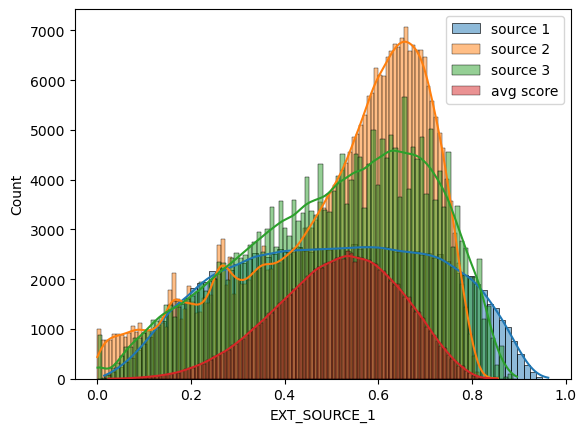

```python
# Create histograms for 'EXT_SOURCE_1', 'EXT_SOURCE_2', 'EXT_SOURCE_3', and the average score
sns.histplot(df['EXT_SOURCE_1'], label='source 1', kde=True)
sns.histplot(df['EXT_SOURCE_2'], label='source 2', kde=True)
sns.histplot(df['EXT_SOURCE_3'], label='source 3', kde=True)
sns.histplot(score, label='avg score', kde=True)

plt.legend()
plt.show()
```

```python
# Display descriptive statistics for the 'EXT_SOURCE' columns and the average score
score.describe()
```

```
count    109589.000000
mean          0.511365
std           0.130859
min           0.023705
25%           0.423705
50%           0.519849
75%           0.607925
max           0.853417
dtype: float64
```

```python
# Remove 'EXT_SOURCE_1' from the list of columns to be dropped
df[['EXT_SOURCE_1','EXT_SOURCE_2','EXT_SOURCE_3']].describe()
```

|  | EXT_SOURCE_1 | EXT_SOURCE_2 | EXT_SOURCE_3 |
| --- | --- | --- | --- |
| count | 134133.000000 | 3.068510e+05 | 246546.000000 |
| mean | 0.502130 | 5.143927e-01 | 0.510853 |
| std | 0.211062 | 1.910602e-01 | 0.194844 |
| min | 0.014568 | 8.173617e-08 | 0.000527 |
| 25% | 0.334007 | 3.924574e-01 | 0.370650 |
| 50% | 0.505998 | 5.659614e-01 | 0.535276 |
| 75% | 0.675053 | 6.636171e-01 | 0.669057 |
| max | 0.962693 | 8.549997e-01 | 0.896010 |

```python
na_list.remove('EXT_SOURCE_1')
```

# Drop the columns

```python
## Drop the columns
dff=df.drop(columns=na_list,axis=1)
```

```python
# Drop the 'SK_ID_CURR' column from the dataframe
dff.drop(['SK_ID_CURR'], axis = 1, inplace = True)
```

```python
# Display descriptive statistics for the modified dataframe 'dff'
dff.describe()
```

|  | TARGET | CNT_CHILDREN | AMT_INCOME_TOTAL | AMT_CREDIT | AMT_ANNUITY | AMT_GOODS_PRICE | REGION_POPULATION_RELATIVE | DAYS_BIRTH | DAYS_EMPLOYED | DAYS_REGISTRATION | ... | FLAG_DOCUMENT_18 | FLAG_DOCUMENT_19 | FLAG_DOCUMENT_20 | FLAG_DOCUMENT_21 | AMT_REQ_CREDIT_BUREAU_HOUR | AMT_REQ_CREDIT_BUREAU_DAY | AMT_REQ_CREDIT_BUREAU_WEEK | AMT_REQ_CREDIT_BUREAU_MON | AMT_REQ_CREDIT_BUREAU_QRT | AMT_REQ_CREDIT_BUREAU_YEAR |
| --- | --- | --- | --- | --- | --- | --- | --- | --- | --- | --- | --- | --- | --- | --- | --- | --- | --- | --- | --- | --- | --- |
| count | 307511.000000 | 307511.000000 | 3.075110e+05 | 3.075110e+05 | 307499.000000 | 3.072330e+05 | 307511.000000 | 307511.000000 | 307511.000000 | 307511.000000 | ... | 307511.000000 | 307511.000000 | 307511.000000 | 307511.000000 | 265992.000000 | 265992.000000 | 265992.000000 | 265992.000000 | 265992.000000 | 265992.000000 |
| mean | 0.080729 | 0.417052 | 1.687979e+05 | 5.990260e+05 | 27108.573909 | 5.383962e+05 | 0.020868 | -16036.995067 | 63815.045904 | -4986.120328 | ... | 0.008130 | 0.000595 | 0.000507 | 0.000335 | 0.006402 | 0.007000 | 0.034362 | 0.267395 | 0.265474 | 1.899974 |
| std | 0.272419 | 0.722121 | 2.371231e+05 | 4.024908e+05 | 14493.737315 | 3.694465e+05 | 0.013831 | 4363.988632 | 141275.766519 | 3522.886321 | ... | 0.089798 | 0.024387 | 0.022518 | 0.018299 | 0.083849 | 0.110757 | 0.204685 | 0.916002 | 0.794056 | 1.869295 |
| min | 0.000000 | 0.000000 | 2.565000e+04 | 4.500000e+04 | 1615.500000 | 4.050000e+04 | 0.000290 | -25229.000000 | -17912.000000 | -24672.000000 | ... | 0.000000 | 0.000000 | 0.000000 | 0.000000 | 0.000000 | 0.000000 | 0.000000 | 0.000000 | 0.000000 | 0.000000 |
| 25% | 0.000000 | 0.000000 | 1.125000e+05 | 2.700000e+05 | 16524.000000 | 2.385000e+05 | 0.010006 | -19682.000000 | -2760.000000 | -7479.500000 | ... | 0.000000 | 0.000000 | 0.000000 | 0.000000 | 0.000000 | 0.000000 | 0.000000 | 0.000000 | 0.000000 | 0.000000 |
| 50% | 0.000000 | 0.000000 | 1.471500e+05 | 5.135310e+05 | 24903.000000 | 4.500000e+05 | 0.018850 | -15750.000000 | -1213.000000 | -4504.000000 | ... | 0.000000 | 0.000000 | 0.000000 | 0.000000 | 0.000000 | 0.000000 | 0.000000 | 0.000000 | 0.000000 | 1.000000 |
| 75% | 0.000000 | 1.000000 | 2.025000e+05 | 8.086500e+05 | 34596.000000 | 6.795000e+05 | 0.028663 | -12413.000000 | -289.000000 | -2010.000000 | ... | 0.000000 | 0.000000 | 0.000000 | 0.000000 | 0.000000 | 0.000000 | 0.000000 | 0.000000 | 0.000000 | 3.000000 |
| max | 1.000000 | 19.000000 | 1.170000e+08 | 4.050000e+06 | 258025.500000 | 4.050000e+06 | 0.072508 | -7489.000000 | 365243.000000 | 0.000000 | ... | 1.000000 | 1.000000 | 1.000000 | 1.000000 | 4.000000 | 9.000000 | 8.000000 | 27.000000 | 261.000000 | 25.000000 |

8 rows × 62 columns

```python
# Display information about the dataframe 'dff'
dff.info(verbose = True)
```

```
<class 'pandas.core.frame.DataFrame'>
RangeIndex: 307511 entries, 0 to 307510
Data columns (total 74 columns):
 #   Column                       Non-Null Count   Dtype
---  ------                       --------------   -----
 0   TARGET                       307511 non-null  int64
 1   NAME_CONTRACT_TYPE           307511 non-null  object
 2   CODE_GENDER                  307511 non-null  object
 3   FLAG_OWN_CAR                 307511 non-null  object
 4   FLAG_OWN_REALTY              307511 non-null  object
 5   CNT_CHILDREN                 307511 non-null  int64
 6   AMT_INCOME_TOTAL             307511 non-null  float64
 7   AMT_CREDIT                   307511 non-null  float64
 8   AMT_ANNUITY                  307499 non-null  float64
 9   AMT_GOODS_PRICE              307233 non-null  float64
```

[output cut: 66 more lines]

```python
# Display value counts of the 'TARGET' column
dff['TARGET'].value_counts()
```

```
TARGET
0    282686
1     24825
Name: count, dtype: int64
```

# Check the relationship between TARGET and each column

## Order of Priority:

#### NAME_CONTRACT_TYPE

#### CODE_GENDER

#### FLAG_OWN_CAR

#### FLAG_OWN_REALTY

#### CNT_CHILDREN

#### AMT_INCOME_TOTAL

#### OWN CAR AGE

#### OCCUPATION_TYPE

#### ORGANIZATION_TYPE

#### AMT_REQ_CREDIT_BUREAU (HOUR DAY WEEK MON QRT YEAR)

#### FLAG DOCUMENTS (2 3 4 5 6 7 8 9 10 11 12 13 14 15 16 17 18 19 20 21)

#### EXT_SOURCE (1 2 3)

#### AMT_CREDIT

#### AMT_ANNUITY

#### AMT_GOODS_PRICE

#### NAME_INCOME_TYPE

#### NAME_EDUCATION_TYPE

#### NAME_FAMILY_STATUS

#### NAME_HOUSING_TYPE

#### REGION_POPULATION_RELATIVE

#### DAYS_BIRTH

#### DAYS_EMPLOYED

#### DAYS_REGISTRATION

#### DAYS_ID_PUBLISH

#### FLAG_MOBIL

#### FLAG_EMP_PHONE

#### FLAG_WORK_PHONE

#### FLAG_CONT_MOBILE

#### FLAG_PHONE

#### FLAG_EMAIL

#### REGION_RATING_CLIENT

#### REGION_RATING_CLIENT_W_CITY

#### REG_REGION_NOT_LIVE_REGION

#### REG_REGION_NOT_WORK_REGION

#### LIVE_REGION_NOT_WORK_REGION

#### REG_CITY_NOT_LIVE_CITY

#### REG_CITY_NOT_WORK_CITY

#### LIVE_CITY_NOT_WORK_CITY

#### WEEKDAY_APPR_PROCESS_START

#### HOUR_APPR_PROCESS_START

#### OBS_30_CNT_SOCIAL_CIRCLE

#### DEF_30_CNT_SOCIAL_CIRCLE

#### OBS_60_CNT_SOCIAL_CIRCLE

#### DEF_60_CNT_SOCIAL_CIRCLE

#### DAYS_LAST_PHONE_CHANGE

### Default & Non-default

```python
default = dff[dff['TARGET']==1]
non_default = dff[dff['TARGET']==0]
```

### NAME_CONTRACT_TYPE

```python
dff['NAME_CONTRACT_TYPE'].isnull().sum()
```

```
0
```

```python
dff['NAME_CONTRACT_TYPE'].value_counts()
```

```
NAME_CONTRACT_TYPE
Cash loans         278232
Revolving loans     29279
Name: count, dtype: int64
```

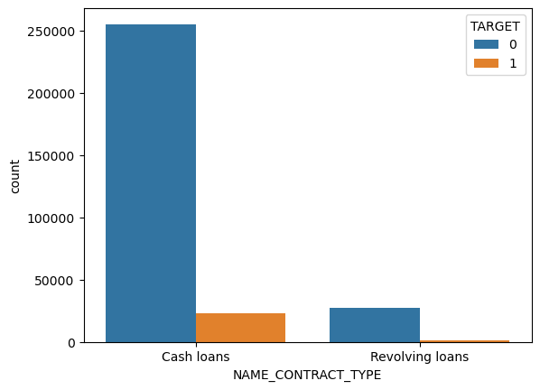

```python
sns.countplot(data=dff, x='NAME_CONTRACT_TYPE', hue='TARGET')
plt.show()
```

```python
default['NAME_CONTRACT_TYPE'].value_counts()*100/dff['NAME_CONTRACT_TYPE'].value_counts()
```

```
NAME_CONTRACT_TYPE
Cash loans         8.345913
Revolving loans    5.478329
Name: count, dtype: float64
```

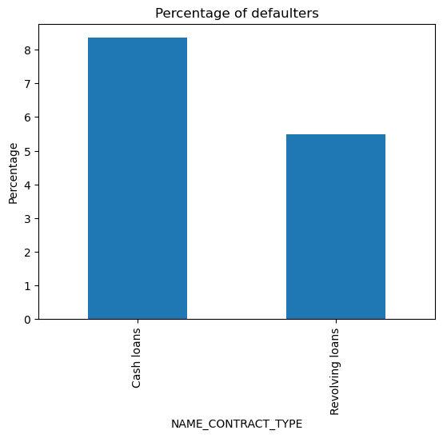

```python
(default['NAME_CONTRACT_TYPE'].value_counts()*100/dff['NAME_CONTRACT_TYPE'].value_counts()).plot(kind='bar')
plt.ylabel('Percentage')
plt.title('Percentage of defaulters')
```

```python
loan_table = pd.crosstab(dff['TARGET'] , dff['NAME_CONTRACT_TYPE'])
```

HYPOTHESIS

Ho : No relation between NAME_CONTRACT_TYPE and TARGET columns Ha : Relationship exist between NAME_CONTRACT_TYPE and TARGET columns

```python
stats.chi2_contingency(loan_table)
```

```
Chi2ContingencyResult(statistic=293.15054219964554, pvalue=1.0235150721172847e-65, dof=1, expected_freq=array([[255770.65910488,  26915.34089512],
       [ 22461.34089512,   2363.65910488]]))
```

#### p-value is very less (of the order of -65) and hence < 0.05. Hence reject the null hypothesis.

#### Thus there is a significant relationship between NAME_CONTRACT_TYPE and TARGET columns

### CODE_GENDER

```python
dff['CODE_GENDER'].isnull().sum()
```

```
0
```

```python
dff['CODE_GENDER'].value_counts()
```

```
CODE_GENDER
F      202448
M      105059
XNA         4
Name: count, dtype: int64
```

```python
dff['CODE_GENDER'] = dff['CODE_GENDER'].apply(lambda x: dff['CODE_GENDER'].mode()[0] if x =='XNA' else x)
```

```python
default['CODE_GENDER'].value_counts()*100/len(default)
```

```
CODE_GENDER
F    57.079557
M    42.920443
Name: count, dtype: float64
```

```python
(default['CODE_GENDER'].value_counts()*100/dff['CODE_GENDER'].value_counts())
```

```
CODE_GENDER
F     6.99919
M    10.14192
Name: count, dtype: float64
```

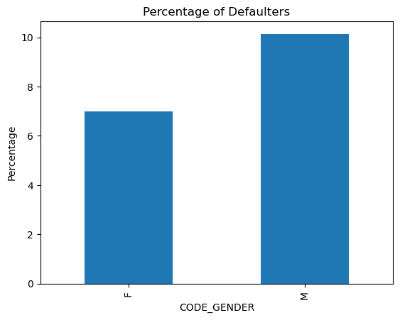

```python
(default['CODE_GENDER'].value_counts()*100/dff['CODE_GENDER'].value_counts()).plot(kind='bar')
plt.title('Percentage of Defaulters')
plt.ylabel('Percentage')
```

```python
gender_table = pd.crosstab(dff['TARGET'] ,dff['CODE_GENDER'])
```

HYPOTHESIS

Ho : No relation between CODE_GENDER and TARGET columns Ha : Relationship exist between CODE_GENDER and TARGET columns

```python
stats.chi2_contingency(gender_table)
```

```
Chi2ContingencyResult(statistic=920.1038473528081, pvalue=4.183493188620687e-202, dof=1, expected_freq=array([[186108.28904332,  96577.71095668],
       [ 16343.71095668,   8481.28904332]]))
```

#### p-value is very less (of the order of -202) and hence < 0.05. Hence reject the null hypothesis.

#### Thus there is a significant relationship between CODE_GENDER and TARGET columns

### FLAG_OWN_CAR

```python
dff['FLAG_OWN_CAR'].isnull().sum()
```

```
0
```

```python
dff['FLAG_OWN_CAR'].value_counts() # need to convert the data to 0 and 1
```

```
FLAG_OWN_CAR
N    202924
Y    104587
Name: count, dtype: int64
```

```python
bp = default['FLAG_OWN_CAR'].value_counts()*100/dff['FLAG_OWN_CAR'].value_counts()
bp
```

```
FLAG_OWN_CAR
N    8.500227
Y    7.243730
Name: count, dtype: float64
```

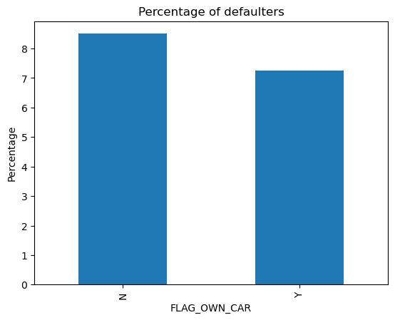

```python
bp.plot(kind='bar')
plt.title('Percentage of defaulters')
plt.ylabel('Percentage')
```

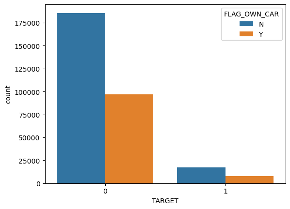

```python
sns.countplot(x = dff['TARGET'] , hue= dff['FLAG_OWN_CAR'])
```

```python
car = pd.crosstab(dff['TARGET'] ,dff['FLAG_OWN_CAR'])
```

HYPOTHESIS

Ho : No relation between FLAG_OWN_CAR and TARGET columns Ha : Relationship exist between FLAG_OWN_CAR and TARGET columns

```python
stats.chi2_contingency(car)
```

```
Chi2ContingencyResult(statistic=146.65601825576024, pvalue=9.330994431109667e-34, dof=1, expected_freq=array([[186542.18504054,  96143.81495946],
       [ 16381.81495946,   8443.18504054]]))
```

#### p-value is very less (of the order of -34) and hence < 0.05. Hence reject the null hypothesis.

#### Thus there is a significant relationship between FLAG_OWN_CAR and TARGET columns

### FLAG_OWN_REALTY

```python
dff['FLAG_OWN_REALTY'].isnull().sum()
```

```
0
```

```python
dff['FLAG_OWN_REALTY'].value_counts()
```

```
FLAG_OWN_REALTY
Y    213312
N     94199
Name: count, dtype: int64
```

```python
realty = dff[dff['TARGET']==1]['FLAG_OWN_REALTY'].value_counts()*100/dff['FLAG_OWN_REALTY'].value_counts()
realty
```

```
FLAG_OWN_REALTY
Y    7.961577
N    8.324929
Name: count, dtype: float64
```

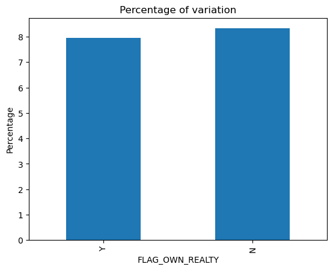

```python
realty.plot(kind='bar')
plt.title('Percentage of variation')
plt.ylabel('Percentage')
```

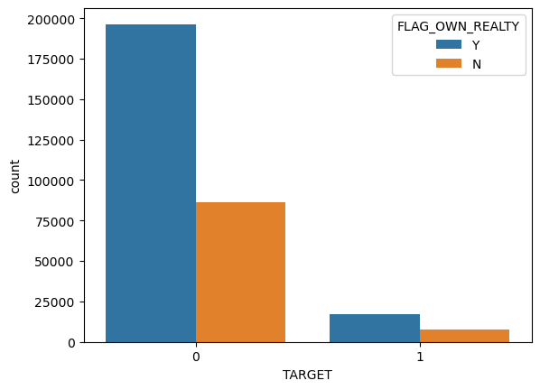

```python
sns.countplot(x = dff['TARGET'] ,hue= dff['FLAG_OWN_REALTY'])
```

```python
realty = pd.crosstab(dff['TARGET'] ,dff['FLAG_OWN_REALTY'])
```

HYPOTHESIS

Ho : No relation between FLAG_OWN_REALTY and TARGET columns Ha : Relationship exist between FLAG_OWN_REALTY and TARGET columns

```python
stats.chi2_contingency(realty)
```

```
Chi2ContingencyResult(statistic=11.575827298084178, pvalue=0.0006681470317545887, dof=1, expected_freq=array([[ 86594.42593598, 196091.57406402],
       [  7604.57406402,  17220.42593598]]))
```

#### Thus there is a significant relationship between FLAG_OWN_REALTY and TARGET columns

### CNT_CHILDREN

```python
dff['CNT_CHILDREN'].isnull().sum()
```

```
0
```

```python
dff['CNT_CHILDREN'].value_counts()
```

```
CNT_CHILDREN
0     215371
1      61119
2      26749
3       3717
4        429
5         84
6         21
7          7
14         3
8          2
9          2
12         2
10         2
19         2
11         1
Name: count, dtype: int64
```

```python
l=[]
for i in range(len(dff)):
    if dff['CNT_CHILDREN'][i] >=3 :
        l.append('Others')
    else:
        l.append(dff['CNT_CHILDREN'][i])
# #len(l)
pd.Series(l).value_counts()
```

```
0         215371
1          61119
2          26749
Others      4272
Name: count, dtype: int64
```

```python
dff['CNT_CHILDREN'] = l
dff['CNT_CHILDREN'].value_counts()
```

```
CNT_CHILDREN
0         215371
1          61119
2          26749
Others      4272
Name: count, dtype: int64
```

```python
default = dff[dff['TARGET']==1]
```

```python
c = default['CNT_CHILDREN'].value_counts()*100/dff['CNT_CHILDREN'].value_counts()
c
```

```
CNT_CHILDREN
0          7.711809
1          8.923575
2          8.721821
Others    10.042135
Name: count, dtype: float64
```

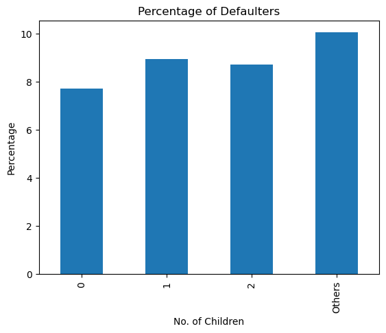

```python
c.plot(kind='bar')
plt.title('Percentage of Defaulters')
plt.ylabel('Percentage')
plt.xlabel('No. of Children')
```

```python
children = pd.crosstab(dff['TARGET'] , dff['CNT_CHILDREN'])
```

HYPOTHESIS

Ho : No relation between CNT_CHILDREN and TARGET columns Ha : Relationship exist between CNT_CHILDREN and TARGET columns

```python
stats.chi2_contingency(children)
```

```
Chi2ContingencyResult(statistic=134.9390128113535, pvalue=4.661845880055693e-29, dof=3, expected_freq=array([[197984.35342476,  56184.93528362,  24589.58480835,
          3927.12648328],
       [ 17386.64657524,   4934.06471638,   2159.41519165,
           344.87351672]]))
```

#### p-value is very less (of the order of -29) and hence < 0.05. Hence reject the null hypothesis.

#### Thus there is a significant relationship between CNT_CHILDREN and TARGET columns

### AMT_INCOME_TOTAL

```python
dff['AMT_INCOME_TOTAL'].isnull().sum()
```

```
0
```

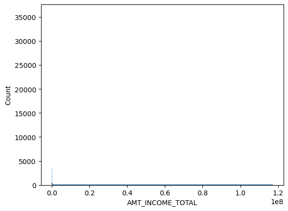

```python
sns.histplot(data=dff, x='AMT_INCOME_TOTAL', kde=True)
plt.show()
```

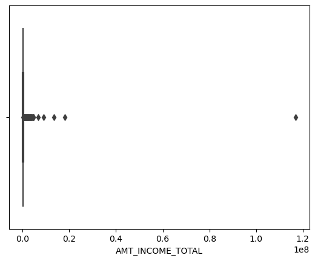

```python
sns.boxplot(data=dff, x='AMT_INCOME_TOTAL')
plt.show()
```

```python
dff['AMT_INCOME_TOTAL'].skew()
```

```
391.5596541041876
```

#### Perform log transformation since AMT_INCOME_TOTAL is highly skewed to the right.

```python
dff['LOG_AMT_INCOME_TOTAL'] = np.log(dff['AMT_INCOME_TOTAL'])
```

```python
dff['LOG_AMT_INCOME_TOTAL'].skew()
```

```
0.16996910947708274
```

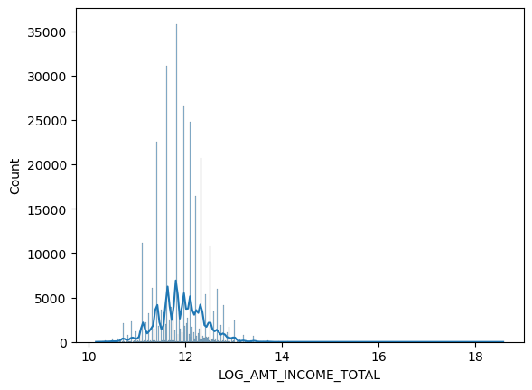

```python
sns.histplot(data=dff, x='LOG_AMT_INCOME_TOTAL', kde=True)
plt.show()
```

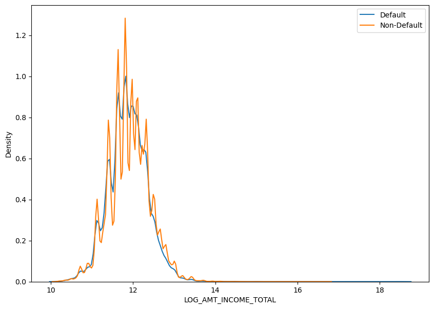

```python
default_copy = default.copy()
non_default_copy = non_default.copy()

default_copy['LOG_AMT_INCOME_TOTAL'] = np.log(default_copy['AMT_INCOME_TOTAL'])
non_default_copy['LOG_AMT_INCOME_TOTAL'] = np.log(non_default_copy['AMT_INCOME_TOTAL'])

plt.figure(figsize=(10, 7))
sns.kdeplot(data=default_copy, x='LOG_AMT_INCOME_TOTAL')
sns.kdeplot(data=non_default_copy, x='LOG_AMT_INCOME_TOTAL')
plt.legend(['Default', 'Non-Default'])
plt.show()
```

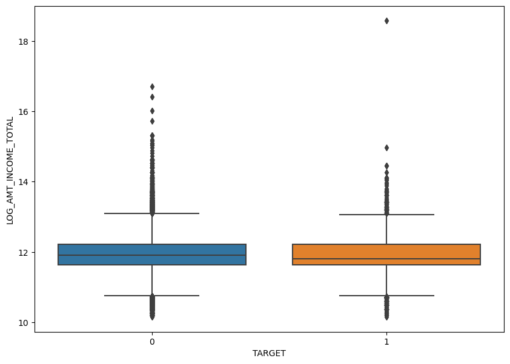

```python
plt.figure(figsize =(10,7))
sns.boxplot(y = dff['LOG_AMT_INCOME_TOTAL'], x = dff['TARGET'])
```

#### Datapoints are densely located right after the whisker lines on both sides.